# Raport 3

Julia Deptulska

2024-11-15

# Zadanie 1

Zestaw danych “Prestige” (z pakietu “car”) zawiera dane nt. prestiżu n=102 Kanadyjskich zawodów z 1971 roku, a także średni dochód w danym zawodzie.

## Wprowadzenie

Załadowanie danych.

```r
data("Prestige")
attach(Prestige)
```

```
## Następujący obiekt został zakryty z package:datasets:
##
##     women
```

Wizualizacja relacji pomiędzy prestiżem a dochodem.

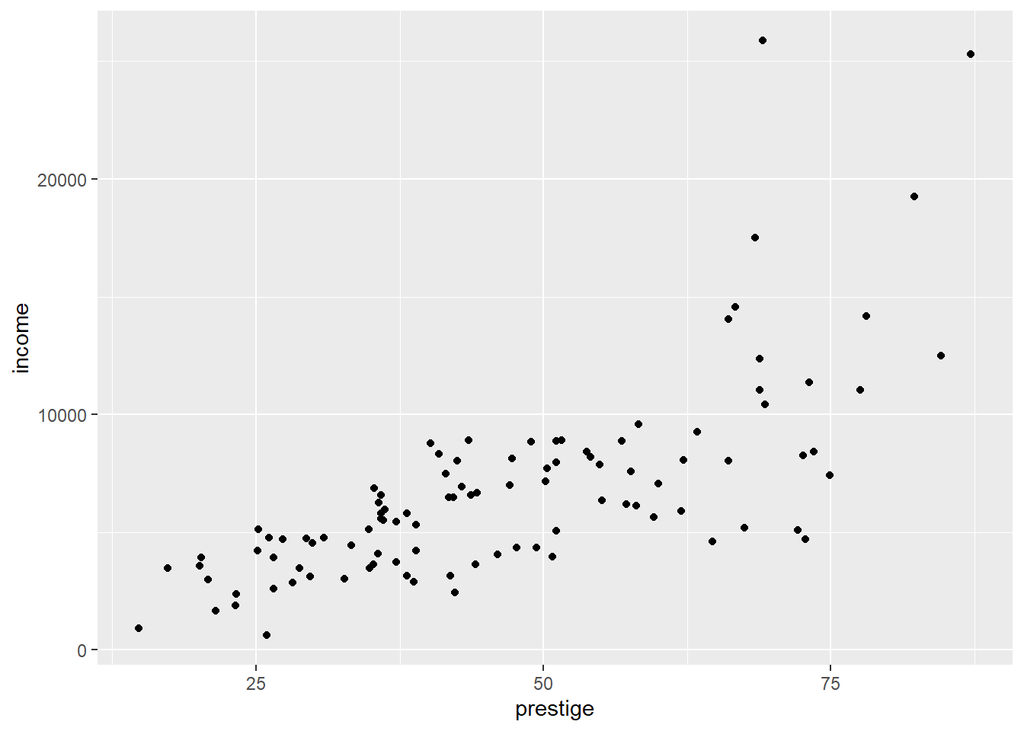

```r
ggplot(Prestige)+
  geom_point(aes(x=prestige, y=income))
```

Związek wygląda na nieliniowy. Dla zawodów, które zarabiają mniej niż $10K, istnieje silna (pozytywna) liniowa zależność pomiędzy dochodem a prestiżem. Jednak w przypadku zawodów, które zarabiają od 10 do 25 tysięcy dolarów, związek ten ma znacznie inne (osłabione) nachylenie.

## Badania zależności między prestiżem a dochodem przy wykorzystaniu metod regresji nieparametrycznej

## Local polynomial regression

### Porównanie różnych szerokości pasm

Dla szerokości równej 5.

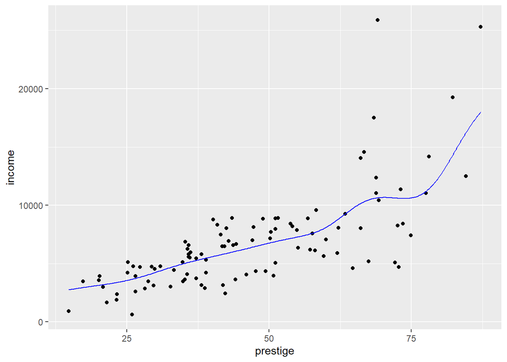

```r
fit1 <- locpoly(prestige, income,
        degree=0, bandwidth=5) %>% as.tibble

ggplot(Prestige) +
  geom_point(aes(x=prestige,y=income)) +
  geom_line(data=fit1, aes(x=x,y=y), col='blue')
```

Dla szerokości równej 1.

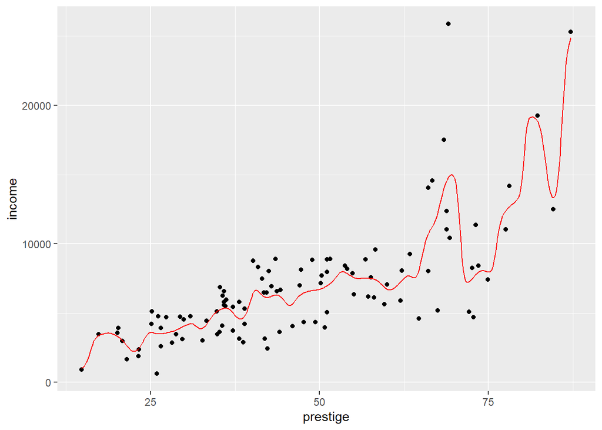

```r
fit2 <- locpoly(prestige, income,
        degree=0, bandwidth=1) %>% as.tibble

ggplot(Prestige) +
  geom_point(aes(x=prestige,y=income)) +
  geom_line(data=fit2, aes(x=x,y=y), col='red')
```

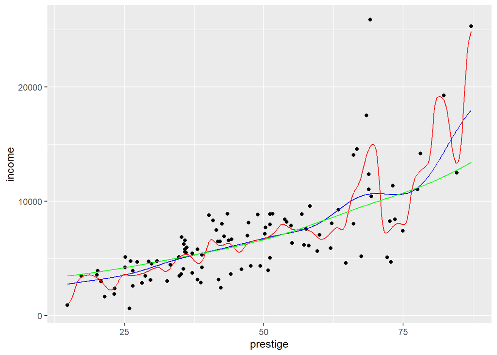

```r
fit3 <- locpoly(prestige, income,
        degree=0, bandwidth=10) %>% as.tibble

ggplot(Prestige) +
  geom_point(aes(x=prestige,y=income)) +
  geom_line(data=fit1, aes(x=x,y=y), col='blue')+
  geom_line(data=fit2, aes(x=x,y=y), col='red')+
  geom_line(data=fit3, aes(x=x,y=y), col='green')
```

Najlepszym wyborem zdaje się być szerokość pasma równa 1, gdyż dopasowuje się odpowiednio do danych.

```r
fitted.value <- dpill(prestige, income)
fit5 <- locpoly(prestige, income,
        degree=0, bandwidth=fitted.value) %>% as.tibble
print(fitted.value)
```

```
## [1] 1.693635
```

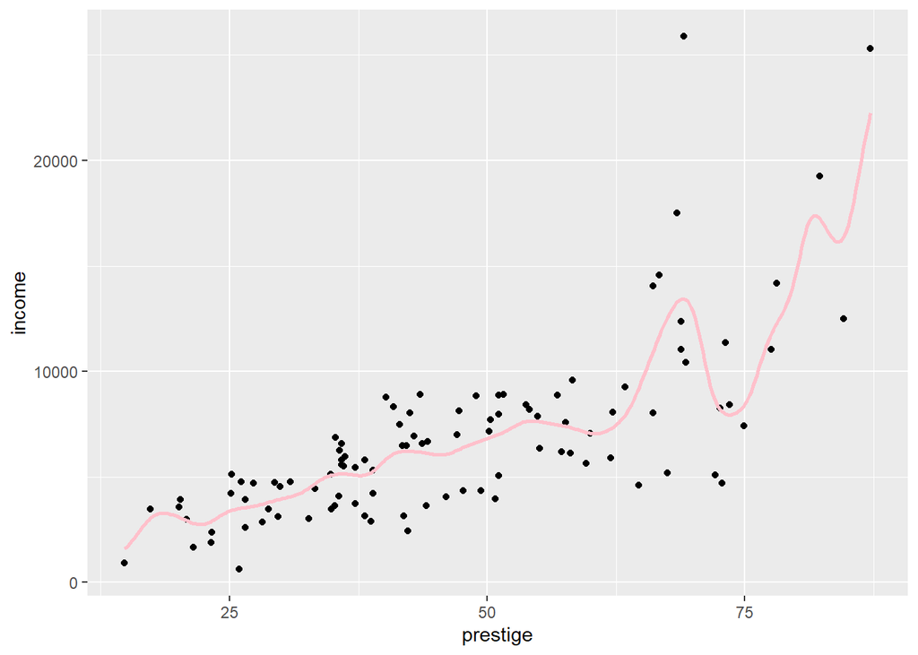

```r
ggplot(Prestige) +
  geom_point(aes(x=prestige,y=income))+
  geom_line(data=fit5, aes(x=x,y=y), col='pink',size=1)
```

### Porównanie różnych stopnii wielomianu

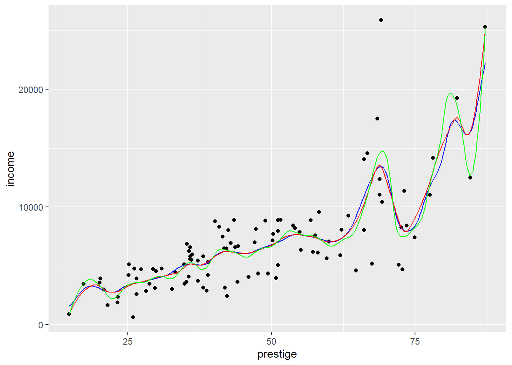

```r
fit5 <- locpoly(prestige, income,
        degree=0, bandwidth=fitted.value) %>% as.tibble
fit6 <- locpoly(prestige, income,
        degree=1, bandwidth=fitted.value) %>% as.tibble
fit7 <- locpoly(prestige, income,
        degree=2, bandwidth=fitted.value) %>% as.tibble

ggplot(Prestige) +
  geom_point(aes(x=prestige,y=income)) +
  geom_line(data=fit5, aes(x=x,y=y), col='blue')+
  geom_line(data=fit6, aes(x=x,y=y), col='red')+
  geom_line(data=fit7, aes(x=x,y=y), col='green')
```

## Lokalna regresja wielomianowa

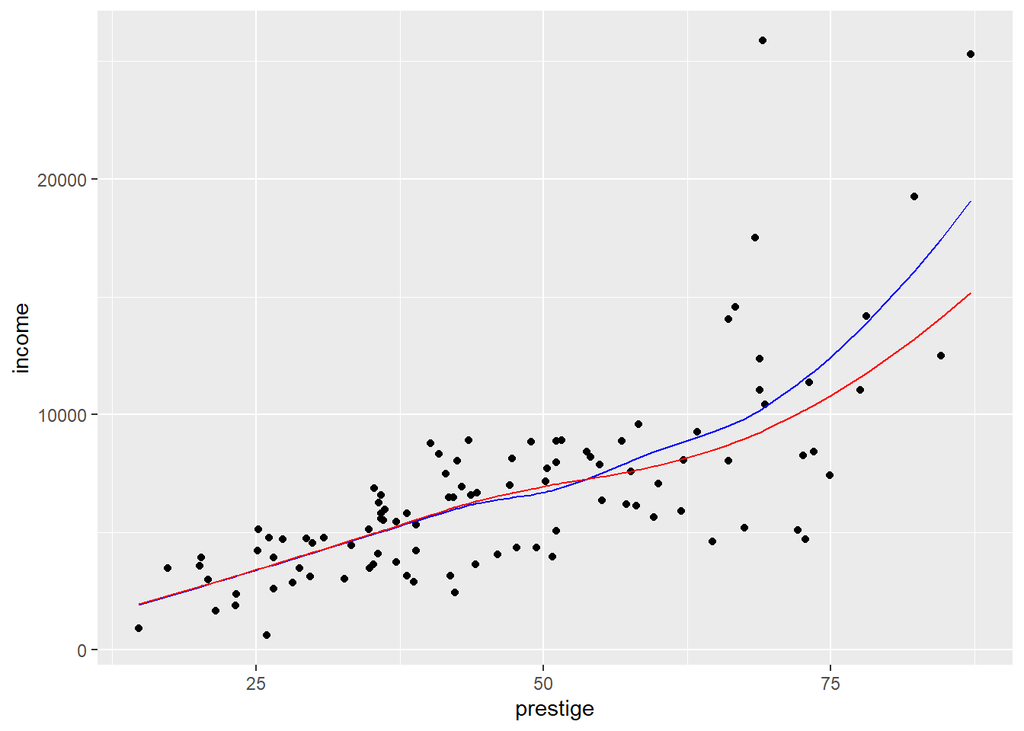

```r
l <- loess(income~prestige, span=0.75, degree=2,
               family="gaussian")
l2 <- loess(income~prestige, span=0.75, degree=2,
               family="symmetric")

ggplot(Prestige) +
  geom_point(aes(x=prestige,y=income))+
  geom_line(aes(x=prestige,y=fitted(l)), col='blue') +
  geom_line(aes(x=prestige,y=fitted(l2)), col='red')
```

Przy 75% pokrytych danych i wielomianie stopnia drugiego najlepiej się sprawdza dopasowanie “symmetric”, gdzie stosowany jest re-descendujący estymator M z funkcją biweight Tukeya.

## Sploty interpolujące

### Zmienianie parametru ‘spar’

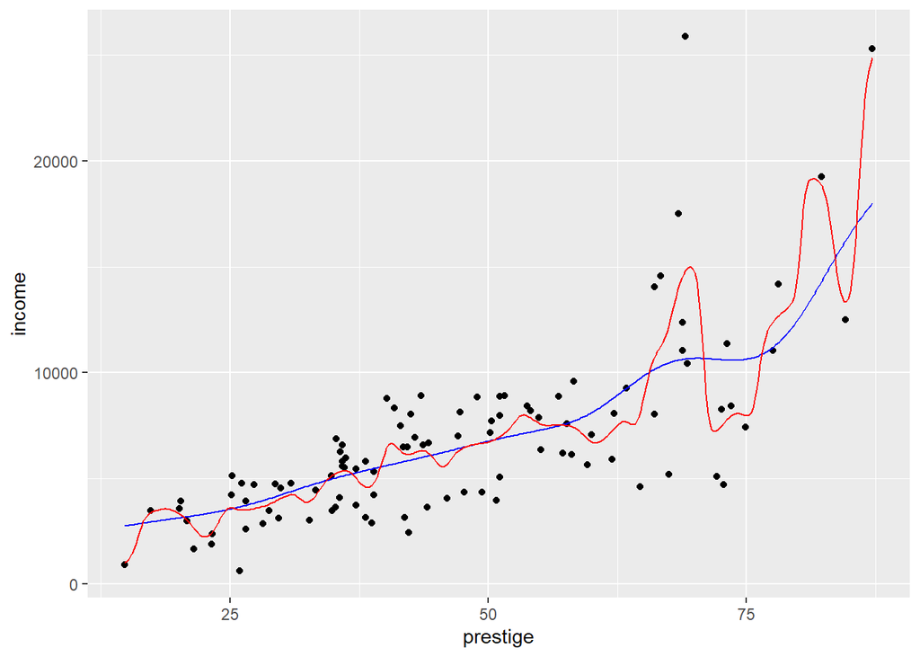

```r
spar1 <-smooth.spline(prestige, income, spar=0.25)
sp <- data.frame(x=fit1$x,y=fit1$y)

spar2 <-smooth.spline(prestige, income, spar=0.75)
sp2 <- data.frame(x=fit2$x,y=fit2$y)

ggplot(Prestige) +
  geom_point(aes(x=prestige,y=income)) +
  geom_line(data=sp, aes(x=x,y=y), col='blue')+
  geom_line(data=sp2, aes(x=x,y=y), col='red')
```

### Zastosowanie cross validation

Lambda zostaje wybrana przez CV.

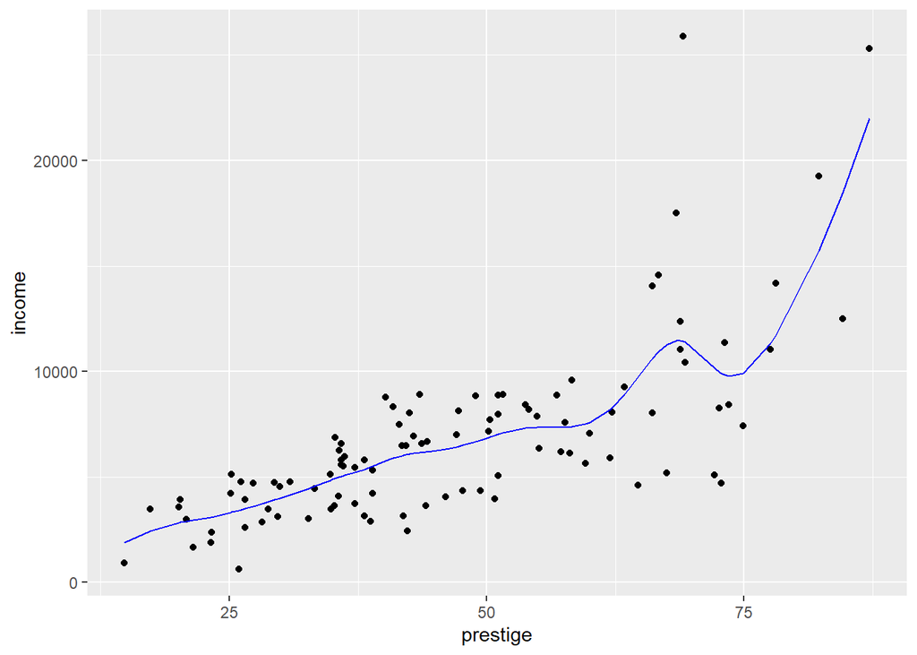

```r
smr2 <- smooth.spline(
  prestige,
  income,
  cv=TRUE)
smr2 <- data.frame(x=smr2$x,y=smr2$y)
ggplot(Prestige) +
  geom_point(aes(x=prestige,y=income)) +
  geom_line(data=smr2, aes(x=x, y=y), col='blue')
```

## Naturalne sploty

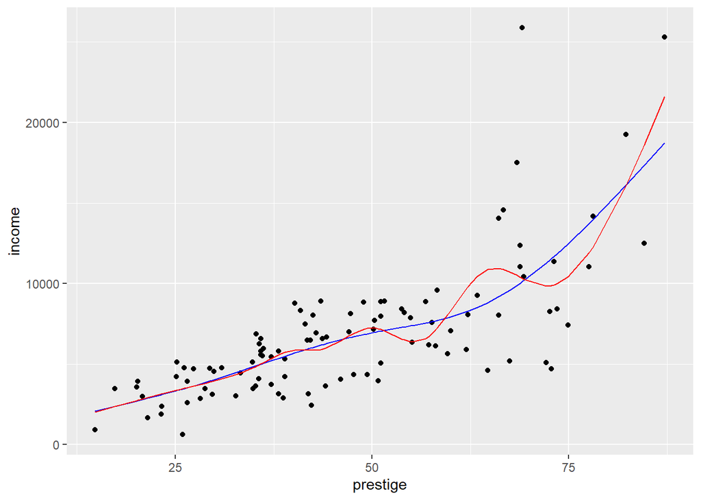

```r
fit <-lm(income~ns(prestige,df=5),Prestige)
fit2 <-lm(income~ns(prestige,df=10),Prestige)

ggplot(Prestige)+
  geom_point(aes(x=prestige,y=income))+
  geom_line(aes(x=prestige,y=fitted(fit)),col='blue')+
  geom_line(aes(x=prestige,y=fitted(fit2)),col='red')
```

Parametr węzłów równy 5 dopasowuje się lepiej do danych.

## Sploty

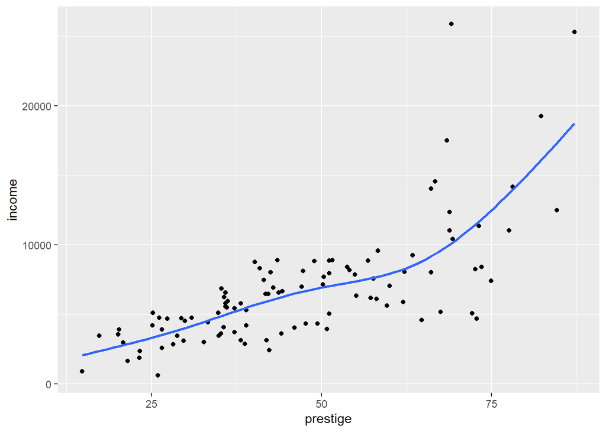

```r
ggplot(Prestige) +
    geom_point(aes(x=prestige,y=income)) +
    geom_smooth(aes(x=prestige,y=fitted(fit)), method='gam',
      formula = y ~ s(x,k=12), se=TRUE)
```

# Zadanie 2.

Zbiór danych “mcycle” (z pakietu MASS) zawiera n=133 pary punktów czasowych (w ms) i obserwowanych przyspieszeń głowy (w g), które zostały zarejestrowane w symulowanym wypadku motocyklowym.

## Wprowadzenie

Załadowanie danych

```r
data("mcycle")
attach(mcycle)
```

Wizualizacja zależności między czasem (X) a przyspieszeniem (Y).

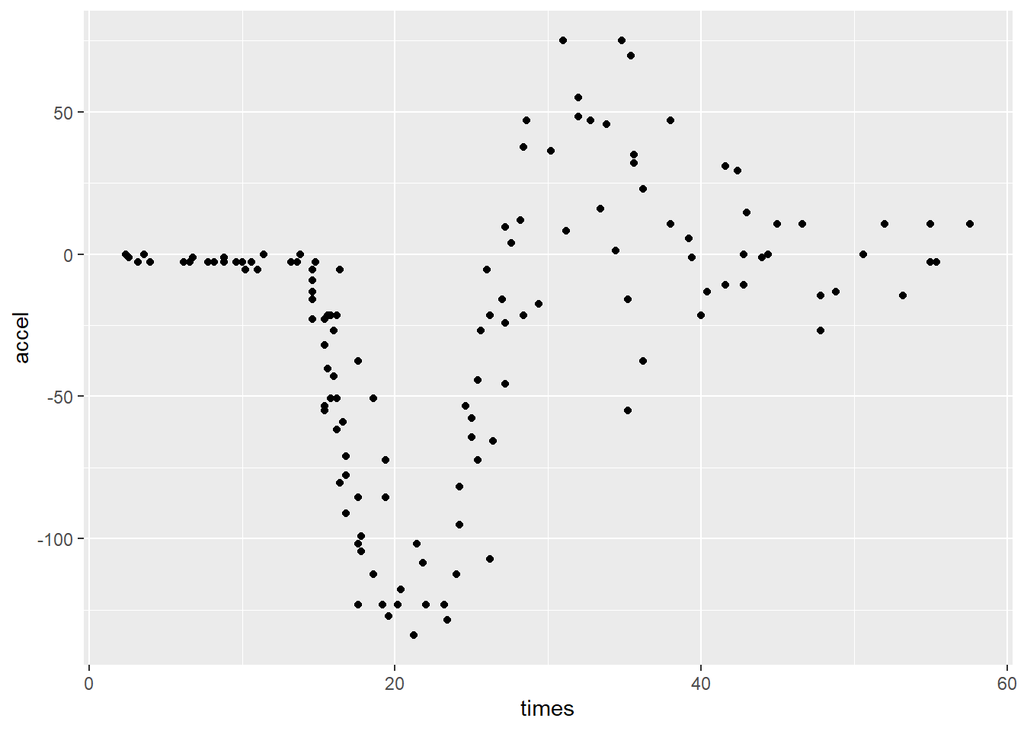

```r
ggplot(mcycle)+
  geom_point(aes(x=times,y=accel))
```

Zależność wygląda na nieliniową.Przyspieszenie jest stabilne od 0-15 ms, spada od ok. 15-20 ms, rośnie od 20-30 ms, spada od 30-40 ms, a następnie zaczyna się stabilizować

## Badania zależności między czasem a przyspieszeniem przy wykorzystaniu metody regresji nieparametrycznej

## Local polynomial regression

### Porównanie różnych szerokości pasm

Porównanie trzech różnych szerokości na jednym wykresie.Dobrano wielkości 1,5 i 10, którym przyporządkowano następująco kolor niebieski, czerwony i zielony.

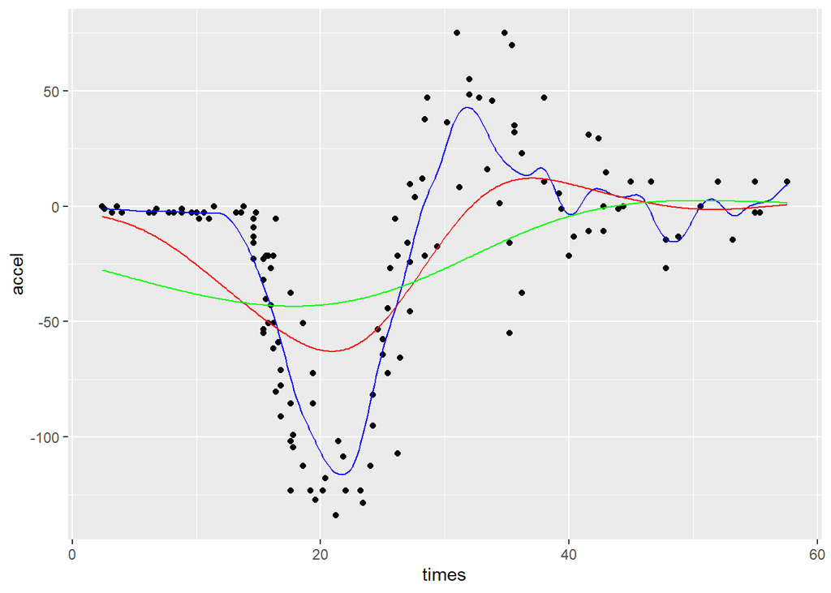

```r
fit1 <- locpoly(times, accel,
        degree=0, bandwidth=1) %>% as.tibble
fit2 <- locpoly(times, accel,
        degree=0, bandwidth=5) %>% as.tibble
fit3 <- locpoly(times, accel,
        degree=0, bandwidth=10) %>% as.tibble

ggplot(mcycle) +
  geom_point(aes(x=times,y=accel)) +
  geom_line(data=fit1, aes(x=x,y=y), col='blue')+
  geom_line(data=fit2, aes(x=x,y=y), col='red') +
  geom_line(data=fit3, aes(x=x,y=y), col='green')
```

```r
fitted.value <- dpill(times, accel)
fit4 <- locpoly(times, accel,
        degree=0, bandwidth=fitted.value) %>% as.tibble
print(fitted.value)
```

```
## [1] 1.445258
```

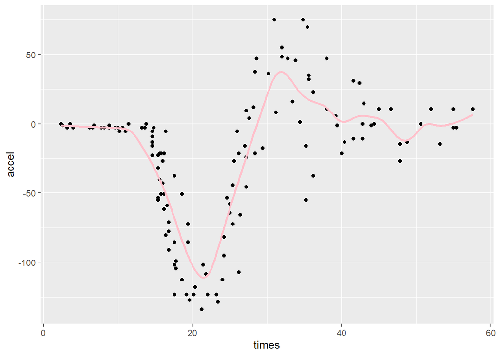

```r
ggplot(mcycle) +
  geom_point(aes(x=times,y=accel))+
  geom_line(data=fit4, aes(x=x,y=y), col='pink',size=1)
```

### Porównanie różnych stopnii wielomianu

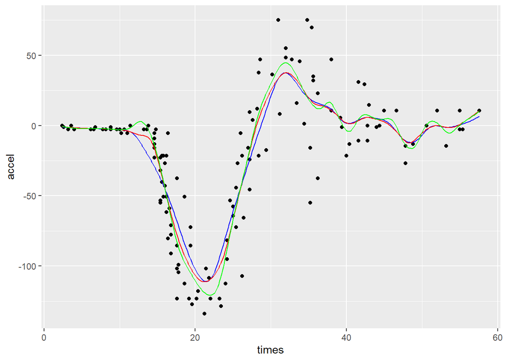

```r
fit6 <- locpoly(times, accel,
        degree=0, bandwidth=fitted.value) %>% as.tibble
fit7 <- locpoly(times, accel,
        degree=1, bandwidth=fitted.value) %>% as.tibble
fit8 <- locpoly(times, accel,
        degree=2, bandwidth=fitted.value) %>% as.tibble

ggplot(mcycle) +
  geom_point(aes(x=times,y=accel)) +
  geom_line(data=fit6, aes(x=x,y=y), col='blue')+
  geom_line(data=fit7, aes(x=x,y=y), col='red')+
  geom_line(data=fit8, aes(x=x,y=y), col='green')
```

Najlepiej na powyższym wykresie wypada wielomian o stopniu zerowym.

## Lokalna regresja wielomianowa

```r
accel~times
```

```
## accel ~ times
```

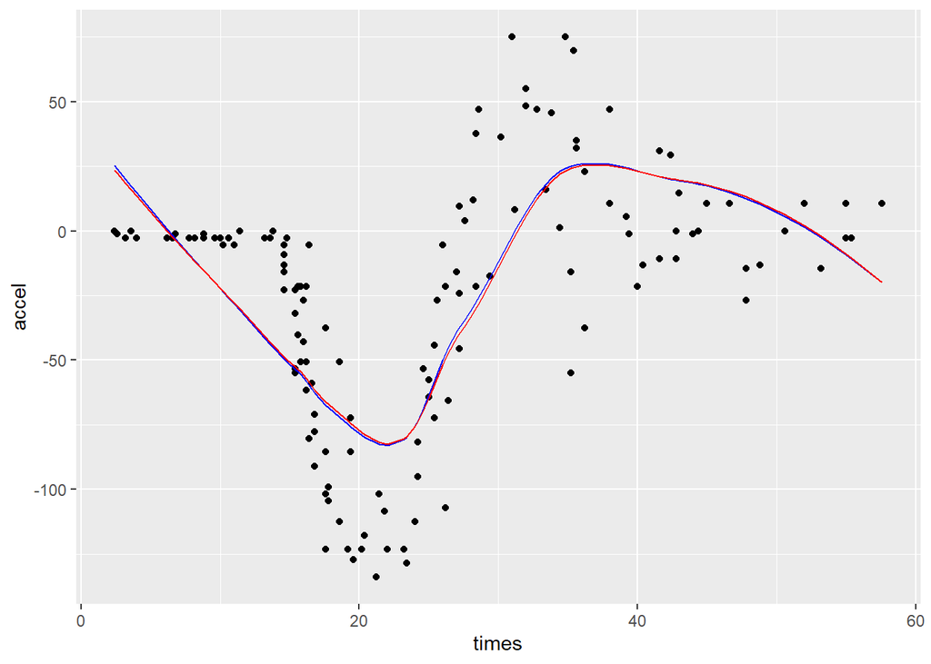

```r
l <- loess (accel~times,span=0.75, degree=2,
               family="gaussian")
l1 <- loess (accel~times,span=0.75, degree=2,
               family="symmetric")

ggplot(mcycle) +
  geom_point(aes(x=times,y=accel))+
  geom_line(aes(x=times,y=fitted(l)), col='blue')+
  geom_line(aes(x=times,y=fitted(l1)), col='red')
```

Przy 75% pokrytych danych i wielomianie stopnia drugiego najlepiej sprawdzają się zarówno dopasowanie “symmetric”, gdzie stosowany jest re-descendujący estymator M z funkcją biweight Tukey jak i dopasowanie “gaussian” odbywające się metodą najmniejszych kwadratów.

## Sploty interpolujące - smooth.spline

### Zmienianie parametru ‘spar’

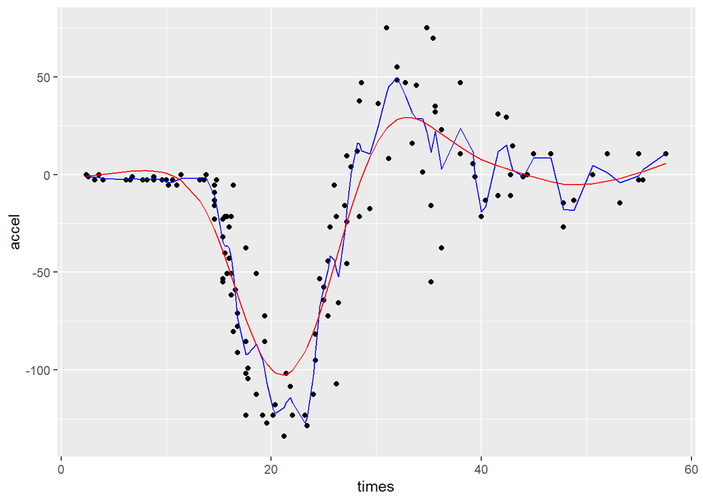

```r
fit1 <-smooth.spline(times, accel, spar=0.25)
smr1 <- data.frame(x=fit1$x,y=fit1$y)

fit2 <-smooth.spline(times, accel, spar=0.75)
smr2 <- data.frame(x=fit2$x,y=fit2$y)

ggplot(mcycle) +
  geom_point(aes(x=times,y=accel)) +
  geom_line(data=smr1, aes(x=x,y=y), col='blue')+
  geom_line(data=smr2, aes(x=x,y=y), col='red')
```

Mniejsze wygładzenie (0.25) zdaje się lepiej dopasowywać do danych.

### Zastosowanie cross validation

Lambda zostaje wybrana przez CV.

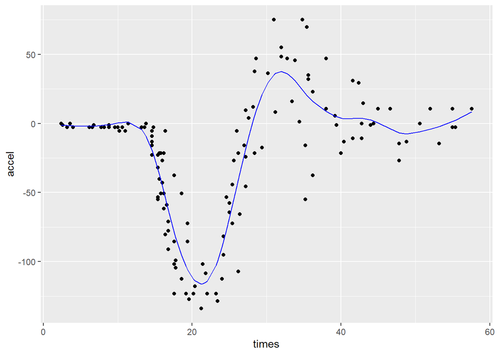

```r
smr2 <- smooth.spline(
  times,
  accel,
  cv=TRUE)
smr2 <- data.frame(x=smr2$x,y=smr2$y)
ggplot(mcycle) +
  geom_point(aes(x=times,y=accel)) +
  geom_line(data=smr2, aes(x=x, y=y), col='blue')
```

## Naturalne sploty

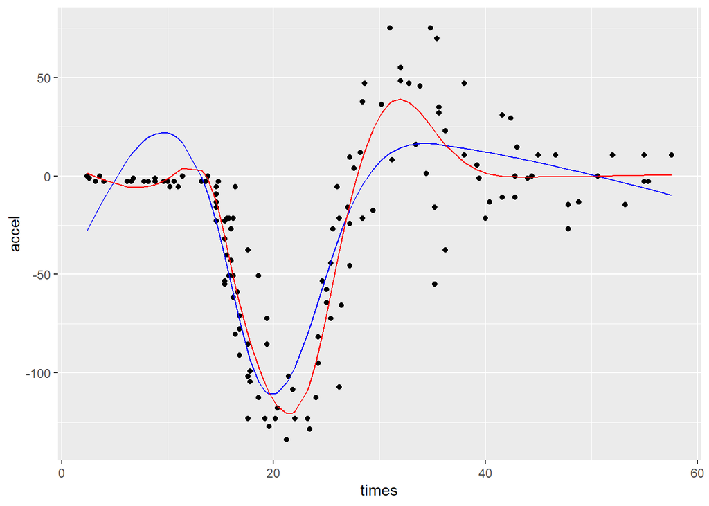

```r
fit <-lm(accel~ns(times,df=5),mcycle)
fit2 <-lm(accel~ns(times,df=10),mcycle)

ggplot(mcycle)+
  geom_point(aes(x=times,y=accel))+
  geom_line(aes(x=times,y=fitted(fit)),col='blue')+
  geom_line(aes(x=times,y=fitted(fit2)),col='red')
```

## Sploty oraz geom_smooth()

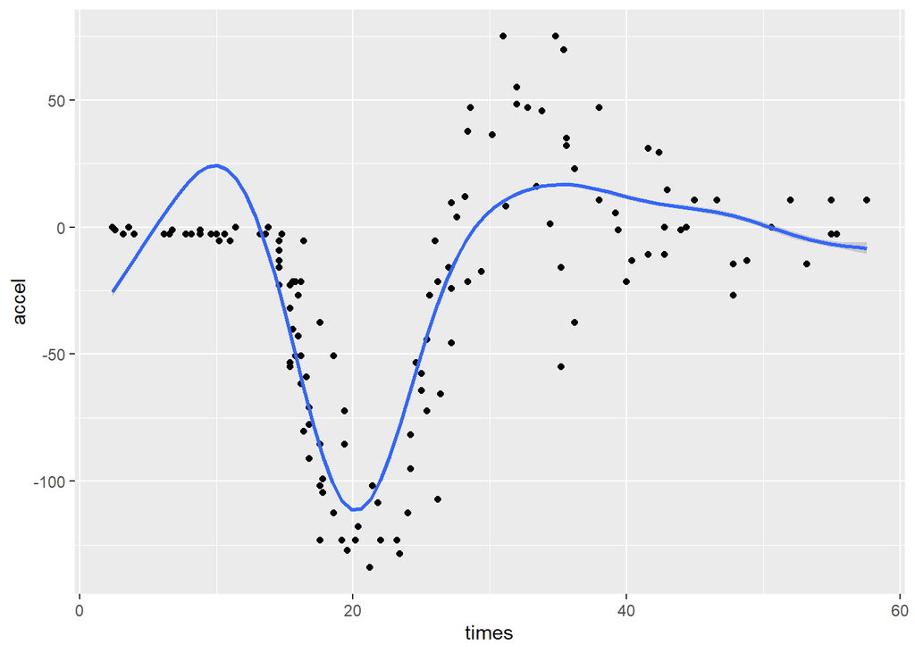

```r
ggplot(mcycle) +
    geom_point(aes(x=times,y=accel)) +
    geom_smooth(aes(x=times,y=fitted(fit)), method='gam',
      formula = y ~ s(x,k=12), se=TRUE)
```